# Problem Set 3

Author

Kai Mao

# 1 Quarto

# 2 Problem 1 - Vision

## 2.1 a.Download the file VIX_D and DEMO_D and merge the two files.

```r
# Load necessary libraries
library(dplyr)
# For read xpt
library(haven)

# Read the VIX_D and DEMO_D dataset
VIX_D <- read_xpt("C:\\Users\\Feixing\\Desktop\\stats 506\\data\\Problem Set 3\\VIX_D.XPT")
DEMO_D <- read_xpt("C:\\Users\\Feixing\\Desktop\\stats 506\\data\\Problem Set 3\\DEMO_D.XPT")

# Merging the datasets by using the SEQN variable
merged_data <- merge(VIX_D, DEMO_D, by = "SEQN")

# Print out total sample size, showing that it is now 6,980.
cat("Total sample size after merging:", nrow(merged_data))
```

```
Total sample size after merging: 6980
```

## 2.2 b. Without fitting any models, estimate the proportion of respondents

### 2.2.1 Explanation of Age Grouping

According to the dataset description, both males and females aged 12 to 150 years are included, and all individuals aged 85 and over are topcoded at 85 years.

Consequently, when processing age data, I have set the age groups as 0-9, 10-19, 20-29, …, 80-84, 85-150. This grouping not only follows the dataset’s encoding rules but also ensures that the analysis covers all possible age segments, including grouping all individuals aged 85 and over into a single category 85-150, to facilitate a comprehensive statistical analysis.

### 2.2.2 Code

```r
# Load necessary libraries
library(dplyr)
library(knitr)
library(kableExtra)
# Create age group boundaries
age_breaks <- c(seq(0, 80, by = 10), 85, 150)

# Use the cut function to create age groups
merged_data$AgeGroup <- cut(merged_data$RIDAGEYR, breaks = age_breaks, right = FALSE, include.lowest = TRUE)

# Calculate the proportion of individuals wearing glasses or contact lenses in each age group
glasses_proportion <- merged_data %>%
  filter(!is.na(VIQ220)) %>%
  group_by(AgeGroup) %>%
  summarise(Count = n(),
            Glasses_Wearers_Count = sum(VIQ220 == 1, na.rm = TRUE),
            Proportion = Glasses_Wearers_Count / Count)

# Use kable to generate a formatted table and add styles with kableExtra
kable(glasses_proportion, format = "html", caption = "Proportion of Glasses/Contact Lenses for Distance Vision Wearers")%>%
  kable_styling(bootstrap_options = c("striped", "hover"))
```

Proportion of Glasses/Contact Lenses for Distance Vision Wearers

| AgeGroup | Count | Glasses_Wearers_Count | Proportion |
| --- | --- | --- | --- |
| [10,20) | 2088 | 670 | 0.3208812 |
| [20,30) | 939 | 306 | 0.3258786 |
| [30,40) | 750 | 269 | 0.3586667 |
| [40,50) | 773 | 286 | 0.3699871 |
| [50,60) | 609 | 335 | 0.5500821 |
| [60,70) | 630 | 392 | 0.6222222 |
| [70,80) | 447 | 299 | 0.6689038 |
| [80,85) | 188 | 125 | 0.6648936 |
| [85,150] | 123 | 83 | 0.6747967 |

## 2.3 c. Fit three logistic regression models predicting whether a respondent wears glasses/contact lenses for distance vision.

```r
# Load necessary libraries
library(dplyr)
library(tidyr)
library(broom)

# Duplicate the original dataset to prevent modification of the original frame.
merged_logistic_data <- merged_data %>%
  # Filter out the 'Don't know' responses for VIQ220 before further processing.
  filter(VIQ220 != 9) %>%
  # Convert vision correction data into a binary format.
  mutate(glasses = as.factor(VIQ220),
         # Convert gender into a binary format, where female = 1 and male = 0.
         gender = as.factor(RIAGENDR),
         # Ensure that race is treated as a factor.
         race = as.factor(RIDRETH1),
         # Include Poverty Income Ratio as it is.
         pir = INDFMPIR) %>%
  # Select necessary columns for modeling.
  select(glasses, RIDAGEYR, race, gender, pir)

# Model 1: Age only.
data1 <- filter(merged_logistic_data, !is.na(RIDAGEYR) & !is.na(glasses))
model1 <- glm(glasses ~ RIDAGEYR, family = binomial(), data = data1)

# Model 2: Age, race, and gender.
data2 <- filter(data1, !is.na(race) & !is.na(gender))
model2 <- glm(glasses ~ RIDAGEYR + race + gender, family = binomial(), data = data2)

# Model 3: Age, race, gender, and Poverty Income Ratio.
data3 <- filter(data2, !is.na(pir))
model3 <- glm(glasses ~ RIDAGEYR + race + gender + pir, family = binomial(), data = data3)

# Extract model coefficients and calculate odds ratios.
coefficients_model1 <- tidy(model1, exponentiate = TRUE) #%>% mutate(Model = "Model 1")
coefficients_model2 <- tidy(model2, exponentiate = TRUE) #%>% mutate(Model = "Model 2")
coefficients_model3 <- tidy(model3, exponentiate = TRUE) #%>% mutate(Model = "Model 3")

# Retrieve statistical information for each model.
stats_model1 <- glance(model1) %>% mutate(Model = "Model 1")
stats_model2 <- glance(model2) %>% mutate(Model = "Model 2")
stats_model3 <- glance(model3) %>% mutate(Model = "Model 3")

# Calculate pseudo R-squared.
# Define null models for baseline comparison.
null_model1 <- glm(glasses ~ 1, family = binomial(), data = data1)
null_model2 <- glm(glasses ~ 1, family = binomial(), data = data2)
null_model3 <- glm(glasses ~ 1, family = binomial(), data = data3)

# Calculate pseudo R-squared values.
pseudo_r2_model1_value <- 1 - as.numeric(logLik(model1) / logLik(null_model1))
pseudo_r2_model2_value <- 1 - as.numeric(logLik(model2) / logLik(null_model2))
pseudo_r2_model3_value <- 1 - as.numeric(logLik(model3) / logLik(null_model3))

# Combine statistical information.
all_models_stats <- bind_rows(
  stats_model1 %>% select(Model, nobs, AIC) %>% mutate(Pseudo_R2 = pseudo_r2_model1_value),
  stats_model2 %>% select(Model, nobs, AIC) %>% mutate(Pseudo_R2 = pseudo_r2_model2_value),
  stats_model3 %>% select(Model, nobs, AIC) %>% mutate(Pseudo_R2 = pseudo_r2_model3_value)
)

# Display model statistics
print(all_models_stats)
```

```
# A tibble: 3 × 4
  Model    nobs   AIC Pseudo_R2
  <chr>   <int> <dbl>     <dbl>
1 Model 1  6545 8476.    0.0497
2 Model 2  6545 8288.    0.0720
3 Model 3  6247 7910.    0.0734
```

```r
# Combine all models' odds ratios.
all_odds_ratios <- bind_rows(coefficients_model1, coefficients_model2, coefficients_model3)

# Output the combined odds ratio table.
print(all_odds_ratios)
```

```
# A tibble: 17 × 5
   term        estimate std.error statistic   p.value
   <chr>          <dbl>     <dbl>     <dbl>     <dbl>
 1 (Intercept)    3.53    0.0534     23.6   4.62e-123
 2 RIDAGEYR       0.976   0.00121   -20.5   4.29e- 93
 3 (Intercept)    6.28    0.0779     23.6   7.81e-123
 4 RIDAGEYR       0.978   0.00126   -17.9   1.63e- 71
 5 race2          0.855   0.164      -0.952 3.41e-  1
 6 race3          0.512   0.0700     -9.55  1.26e- 21
 7 race4          0.770   0.0766     -3.42  6.27e-  4
 8 race5          0.522   0.135      -4.81  1.53e-  6
 9 gender2        0.605   0.0530     -9.47  2.76e- 21
10 (Intercept)    7.51    0.0878     23.0   1.01e-116
11 RIDAGEYR       0.978   0.00129   -17.1   8.12e- 66
12 race2          0.890   0.168      -0.690 4.90e-  1
13 race3          0.606   0.0751     -6.67  2.49e- 11
14 race4          0.813   0.0792     -2.62  8.85e-  3
15 race5          0.587   0.140      -3.80  1.44e-  4
16 gender2        0.597   0.0543     -9.51  1.96e- 21
17 pir            0.893   0.0177     -6.42  1.41e- 10
```

## 2.4 d. From the third model from the previous part, test whether the odds of men and women being wears of glasess/contact lenses for distance vision differs. Test whether the proportion of wearers of glasses/contact lenses for distance vision differs between men and women. Include the results of the each test and their interpretation.

### 2.4.1 Code

```r
logit_model3 <- tidy(model3, exponentiate = TRUE)
print(logit_model3)
```

```
# A tibble: 8 × 5
  term        estimate std.error statistic   p.value
  <chr>          <dbl>     <dbl>     <dbl>     <dbl>
1 (Intercept)    7.51    0.0878     23.0   1.01e-116
2 RIDAGEYR       0.978   0.00129   -17.1   8.12e- 66
3 race2          0.890   0.168      -0.690 4.90e-  1
4 race3          0.606   0.0751     -6.67  2.49e- 11
5 race4          0.813   0.0792     -2.62  8.85e-  3
6 race5          0.587   0.140      -3.80  1.44e-  4
7 gender2        0.597   0.0543     -9.51  1.96e- 21
8 pir            0.893   0.0177     -6.42  1.41e- 10
```

```r
library(margins)
margins_pwcompare <- margins(model3, variables = "gender", pwcompare = TRUE)
summary(margins_pwcompare)
```

```
  factor     AME     SE       z      p   lower   upper
 gender2 -0.1145 0.0119 -9.6425 0.0000 -0.1377 -0.0912
```

# 3 Problem 2 - Sakila

## 3.1 a. What year is the oldest movie from, and how many movies were released in that year?

```r
library(DBI)
library(RSQLite)

sakila <- dbConnect(SQLite(), "C:/Users/Feixing/Desktop/stats 506/data/Problem Set 3/sakila_master.db")

dbGetQuery(sakila, "
SELECT release_year, COUNT(*) AS movie_count
  FROM film
GROUP BY release_year
ORDER BY release_year ASC
           ")
```

```
  release_year movie_count
1         2006        1000
```

The oldest movie from 2006, and 1000 movies were released in that year.

## 3.2 b. What genre of movie is the least common in the data, and how many movies are of this genre?

### 3.2.1 First, use SQL query or queries to extract the appropriate table(s), then use regular R operations on those data.frames to answer the question.

```r
film_category <- dbGetQuery(sakila, "SELECT * FROM film_category")
category <- dbGetQuery(sakila, "SELECT * FROM category")
category_count <- table(film_category$category_id)
min_category <- which.min(category_count)
c(category$name[category$category_id == min_category], category_count[min_category])
```

```
             12
"Music"    "51"
```

### 3.2.2 Second, use a single SQL query.

```r
dbGetQuery(sakila, "
SELECT c.name AS genre, COUNT(fc.film_id) AS movie_count
  FROM category AS c
  JOIN film_category AS fc ON c.category_id = fc.category_id
 GROUP BY c.name
 ORDER BY movie_count
 LIMIT 1
")
```

```
  genre movie_count
1 Music          51
```

## 3.3 c. Identify which country or countries have exactly 13 customers.

### 3.3.1 First, use SQL query or queries to extract the appropriate table(s), then use regular R operations on those data.frames to answer the question.

```r
customer <- dbGetQuery(sakila, "SELECT * FROM customer")
address  <- dbGetQuery(sakila, "SELECT * FROM address")
city     <- dbGetQuery(sakila, "SELECT * FROM city")
country  <- dbGetQuery(sakila, "SELECT * FROM country")
merged1 <- merge(customer, address, by = "address_id")
merged2 <- merge(merged1, city, by = "city_id")
merged3 <- merge(merged2, country, by = "country_id")
conum <- table(merged3$country)
conum[conum == 13]
```

```
Argentina   Nigeria
       13        13
```

### 3.3.2 Second, use a single SQL query.

```r
dbGetQuery(sakila,"
SELECT c.country, count(*) as customer_count
  FROM customer as cu
  JOIN address as a on cu.address_id = a.address_id
       JOIN city as ci on a.city_id = ci.city_id
            JOIN country as c on ci.country_id = c.country_id
  GROUP BY c.country
 HAVING COUNT(*) = 13
")
```

```
    country customer_count
1 Argentina             13
2   Nigeria             13
```

# 4 Problem 3 - US Records

## 4.1 a. What proportion of email addresses are hosted at a domain with TLD “.com”?

```r
library(dplyr)

# Load the data
us_record <- read.csv("C:\\Users\\Feixing\\Desktop\\stats 506\\data\\Problem Set 3\\us-500.csv")

# Calculate the proportion of '.com' TLDs
com_proportion <- mean(grepl('.com$', us_record$email))

# Print the result
cat('Proportion of .com:', com_proportion)
```

```
Proportion of .com: 0.732
```

## 4.2 b. What proportion of email addresses have at least one non alphanumeric character in them?

```r
# Split the email addresses at '@' to separate the username and domain parts
email <- strsplit(us_record$email, "@")

# Extract the username
username <- sapply(email, "[[", 1)

# Extract the domain part from each email address
domains <- sapply(email, "[[", 2)

# Remove the last three characters TLD from each domain to focus on the main domain part
domains <- gsub("\\.[a-z]{3}$", "", domains)

# Check for any non-alphanumeric characters in the usernames
username_nonalphanumeric <- grepl("[^a-zA-Z0-9]", username)

# Check for any non-alphanumeric characters in the domains
domain_nonalphanumeric <- grepl("[^a-zA-Z0-9]", domains)

# Calculate the proportion of email addresses that contain non-alphanumeric characters
mean(username_nonalphanumeric | domain_nonalphanumeric)
```

```
[1] 0.506
```

## 4.3 c. What are the top 5 most common area codes amongst all phone numbers?

```r
# Use the substr function to extract the first three digits from phone number
phone1area <- substr(us_record$phone1, 1, 3)
phone2area <- substr(us_record$phone2, 1, 3)

# Use sort function to sort the frequency of occurrence of area in decreasing
top5area_codes <- sort(table(c(phone1area, phone2area)), decreasing = TRUE)[1:5]
print("Top 5 most common area codes:")
```

```
[1] "Top 5 most common area codes:"
```

```r
print(top5area_codes)
```

```
973 212 215 410 201
 36  28  28  28  24
```

## 4.4 d. Produce a histogram of the log of the apartment numbers for all addresses.

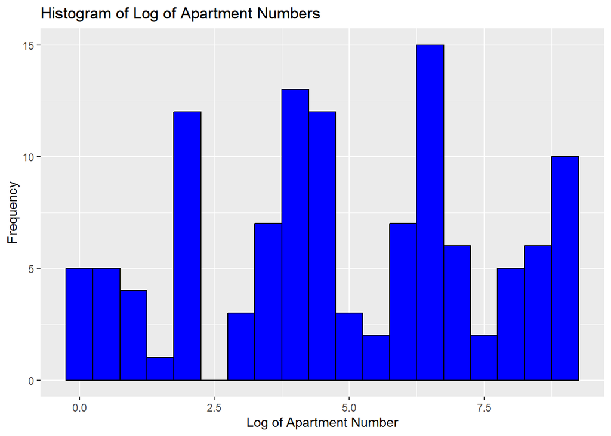

```r
# Load the library
library(ggplot2)

#Use the regmatches and regexpr functions to extract the contained number
apartment_num <- regmatches(us_record$address, regexpr('[0-9]+$', us_record$address))

# Converts the extracted string apartment numbers to numeric numbers
log_apartment_numbers <- log(as.numeric(apartment_num))

# Use ggplot2 to create a histogram
ggplot(data = data.frame(log_apartment_numbers), aes(x = log_apartment_numbers)) +
  geom_histogram(binwidth = 0.5, fill = "blue", color = "black") +
  labs(title = "Histogram of Log of Apartment Numbers",
       x = "Log of Apartment Number", y = "Frequency")
```

## 4.5 e. Examine whether the apartment numbers appear to follow Benford’s law. Do you think the apartment numbers would pass as real data?

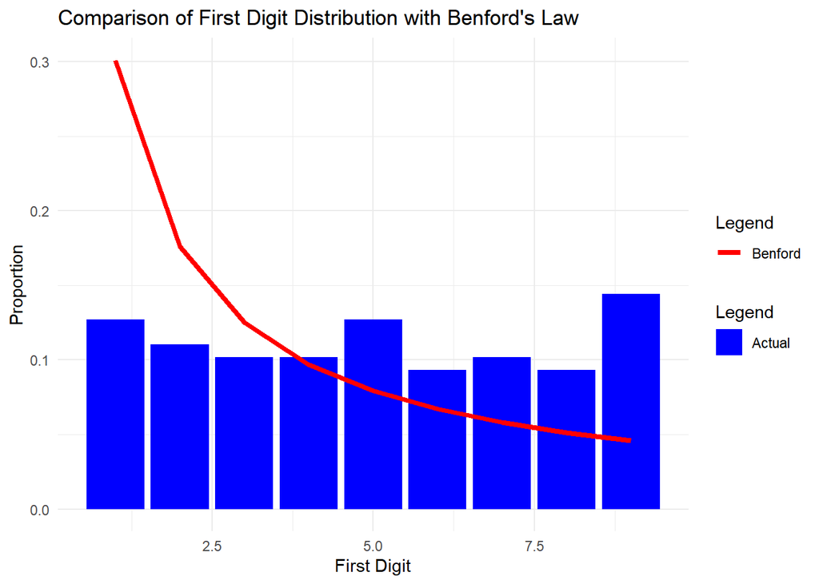

```r
# Extract the first digit
first_digits <- substring(apartment_num, 1, 1) %>% as.numeric()

# Calculate the distribution of the first digit
digit_distribution <- table(first_digits) / length(first_digits)

# Theoretical distribution of Bayford's law
benford_distribution <- log10(1 + 1/(1:9))

# Plot actual distribution versus the theoretical distribution of Bayford's law
df <- data.frame(Digit = 1:9, Actual = as.numeric(digit_distribution[as.character(1:9)]), Benford = benford_distribution)
ggplot(df, aes(x = Digit)) +
  geom_bar(aes(y = Actual, fill = "Actual"), stat = "identity") +
  geom_line(aes(y = Benford, group = 1, colour = "Benford"), size = 1.5) +
  labs(title = "Comparison of First Digit Distribution with Benford's Law",
       x = "First Digit",
       y = "Proportion") +
  scale_fill_manual(name = "Legend", values = c(Actual = "blue")) +
  scale_colour_manual(name = "Legend", values = c(Benford = "red")) +
  theme_minimal()
```

According to the comparison of Benford’s law with the actual data distribution, it can be found that the apartment numbers do not pass as real data. This set of data shows like a uniform distribution, without satifying Benford’s law.

# 5 References and Data Sources

The datasets used in this project are obtained from the following sources:

- **National Health and Nutrition Examination Survey (NHANES) Data**:Includes the Vision (VIX_D) and Demographic (DEMO_D) data from the years 2005-2006. These datasets are from (https://wwwn.cdc.gov/nchs/nhanes/search/datapage.aspx?Component=Examination&CycleBeginYear=2005). The Vision data assess visual acuity and refractive error across the U.S. population, while the Demographic data provides detailed demographic information on sampled individuals and families.
- **Sakila Database**: This database was discussed in class and is available for download from the following link: (https://github.com/bradleygrant/sakila-sqlite3).
- **US - 500 Records Data**: This dataset was downloaded from (https://www.briandunning.com/sample-data/) and imported into R. It is entirely fictitious data, used to answer specific questions posed in the assignment.

# 6 Methods and Implementation

All data analyses were performed in the R environment, employing a range of techniques including data import, data cleaning, statistical analysis, and result visualization.

# 7 Code and Documentation Repository

This document and related code are hosted on GitHub for review and sharing purposes. Access link: [GitHub Repository Link](https://github.com/KKKaiMao/stats506-coursework)

# 8 Acknowledgements

Thanks to the course instructors and teaching assistants for their guidance on this assignment. Thanks to all data providers for supporting open data.

# 9 Notes

The analyses in this document are for academic purposes only, intended to fulfill the requirements of a statistics course. While every reasonable effort has been made to ensure the accuracy of the analysis results, the content of this document represents only the views of the author.